# Risk Factor Analysis

## Outcome Variable

**Outcome Variable:** ever_swasted

## Predictor Variables

**Intervention Variable:** fage

**Adjustment Set:**

- arm
- W_mage
- meducyrs
- feducyrs
- W_mhtcm
- W_mwtkg
- W_mbmi
- W_fhtcm
- single
- brthmon
- delta_W_mage
- delta_meducyrs
- delta_feducyrs
- delta_W_mhtcm
- delta_W_mwtkg
- delta_W_mbmi
- delta_W_fhtcm
- delta_single
- delta_brthmon

## Stratifying Variables

The analysis was stratified on these variable(s):

- agecat
- studyid
- country

## Data Summary

| agecat | studyid | country | fage | ever_swasted | n_cell | n |
| --- | --- | --- | --- | --- | --- | --- |
| 0-24 months | COHORTS | GUATEMALA | >=38 | 0 | 357 | 1285 |
| 0-24 months | COHORTS | GUATEMALA | >=38 | 1 | 25 | 1285 |
| 0-24 months | COHORTS | GUATEMALA | <32 | 0 | 554 | 1285 |
| 0-24 months | COHORTS | GUATEMALA | <32 | 1 | 47 | 1285 |
| 0-24 months | COHORTS | GUATEMALA | [32-38) | 0 | 280 | 1285 |
| 0-24 months | COHORTS | GUATEMALA | [32-38) | 1 | 22 | 1285 |
| 0-24 months | COHORTS | PHILIPPINES | >=38 | 0 | 285 | 2939 |
| 0-24 months | COHORTS | PHILIPPINES | >=38 | 1 | 43 | 2939 |
| 0-24 months | COHORTS | PHILIPPINES | <32 | 0 | 1823 | 2939 |
| 0-24 months | COHORTS | PHILIPPINES | <32 | 1 | 251 | 2939 |
| 0-24 months | COHORTS | PHILIPPINES | [32-38) | 0 | 466 | 2939 |
| 0-24 months | COHORTS | PHILIPPINES | [32-38) | 1 | 71 | 2939 |
| 0-24 months | LCNI-5 | MALAWI | >=38 | 0 | 26 | 106 |
| 0-24 months | LCNI-5 | MALAWI | >=38 | 1 | 0 | 106 |
| 0-24 months | LCNI-5 | MALAWI | <32 | 0 | 56 | 106 |
| 0-24 months | LCNI-5 | MALAWI | <32 | 1 | 0 | 106 |
| 0-24 months | LCNI-5 | MALAWI | [32-38) | 0 | 24 | 106 |
| 0-24 months | LCNI-5 | MALAWI | [32-38) | 1 | 0 | 106 |
| 0-24 months | MAL-ED | BANGLADESH | >=38 | 0 | 63 | 151 |
| 0-24 months | MAL-ED | BANGLADESH | >=38 | 1 | 6 | 151 |
| 0-24 months | MAL-ED | BANGLADESH | <32 | 0 | 28 | 151 |
| 0-24 months | MAL-ED | BANGLADESH | <32 | 1 | 2 | 151 |
| 0-24 months | MAL-ED | BANGLADESH | [32-38) | 0 | 46 | 151 |
| 0-24 months | MAL-ED | BANGLADESH | [32-38) | 1 | 6 | 151 |
| 0-24 months | MAL-ED | BRAZIL | >=38 | 0 | 30 | 79 |
| 0-24 months | MAL-ED | BRAZIL | >=38 | 1 | 0 | 79 |
| 0-24 months | MAL-ED | BRAZIL | <32 | 0 | 18 | 79 |
| 0-24 months | MAL-ED | BRAZIL | <32 | 1 | 0 | 79 |
| 0-24 months | MAL-ED | BRAZIL | [32-38) | 0 | 31 | 79 |
| 0-24 months | MAL-ED | BRAZIL | [32-38) | 1 | 0 | 79 |

[output cut: 204 more lines]

The following strata were considered:

- agecat: 0-24 months, studyid: COHORTS, country: GUATEMALA
- agecat: 0-24 months, studyid: COHORTS, country: PHILIPPINES
- agecat: 0-24 months, studyid: LCNI-5, country: MALAWI
- agecat: 0-24 months, studyid: MAL-ED, country: BANGLADESH
- agecat: 0-24 months, studyid: MAL-ED, country: BRAZIL
- agecat: 0-24 months, studyid: MAL-ED, country: INDIA
- agecat: 0-24 months, studyid: MAL-ED, country: NEPAL
- agecat: 0-24 months, studyid: MAL-ED, country: PERU
- agecat: 0-24 months, studyid: MAL-ED, country: SOUTH AFRICA
- agecat: 0-24 months, studyid: MAL-ED, country: TANZANIA, UNITED REPUBLIC OF
- agecat: 0-24 months, studyid: PROBIT, country: BELARUS
- agecat: 0-24 months, studyid: SAS-CompFeed, country: INDIA
- agecat: 0-24 months, studyid: SAS-FoodSuppl, country: INDIA
- agecat: 0-6 months, studyid: COHORTS, country: GUATEMALA
- agecat: 0-6 months, studyid: COHORTS, country: PHILIPPINES
- agecat: 0-6 months, studyid: LCNI-5, country: MALAWI
- agecat: 0-6 months, studyid: MAL-ED, country: BANGLADESH
- agecat: 0-6 months, studyid: MAL-ED, country: BRAZIL
- agecat: 0-6 months, studyid: MAL-ED, country: INDIA
- agecat: 0-6 months, studyid: MAL-ED, country: NEPAL
- agecat: 0-6 months, studyid: MAL-ED, country: PERU
- agecat: 0-6 months, studyid: MAL-ED, country: SOUTH AFRICA
- agecat: 0-6 months, studyid: MAL-ED, country: TANZANIA, UNITED REPUBLIC OF
- agecat: 0-6 months, studyid: PROBIT, country: BELARUS
- agecat: 0-6 months, studyid: SAS-CompFeed, country: INDIA
- agecat: 0-6 months, studyid: SAS-FoodSuppl, country: INDIA
- agecat: 6-24 months, studyid: COHORTS, country: GUATEMALA
- agecat: 6-24 months, studyid: COHORTS, country: PHILIPPINES
- agecat: 6-24 months, studyid: LCNI-5, country: MALAWI
- agecat: 6-24 months, studyid: MAL-ED, country: BANGLADESH
- agecat: 6-24 months, studyid: MAL-ED, country: BRAZIL
- agecat: 6-24 months, studyid: MAL-ED, country: INDIA
- agecat: 6-24 months, studyid: MAL-ED, country: NEPAL
- agecat: 6-24 months, studyid: MAL-ED, country: PERU
- agecat: 6-24 months, studyid: MAL-ED, country: SOUTH AFRICA
- agecat: 6-24 months, studyid: MAL-ED, country: TANZANIA, UNITED REPUBLIC OF
- agecat: 6-24 months, studyid: PROBIT, country: BELARUS
- agecat: 6-24 months, studyid: SAS-CompFeed, country: INDIA
- agecat: 6-24 months, studyid: SAS-FoodSuppl, country: INDIA

### Dropped Strata

Some strata were dropped due to rare outcomes:

- agecat: 0-24 months, studyid: LCNI-5, country: MALAWI
- agecat: 0-24 months, studyid: MAL-ED, country: BANGLADESH
- agecat: 0-24 months, studyid: MAL-ED, country: BRAZIL
- agecat: 0-24 months, studyid: MAL-ED, country: INDIA
- agecat: 0-24 months, studyid: MAL-ED, country: NEPAL
- agecat: 0-24 months, studyid: MAL-ED, country: PERU
- agecat: 0-24 months, studyid: MAL-ED, country: SOUTH AFRICA
- agecat: 0-24 months, studyid: MAL-ED, country: TANZANIA, UNITED REPUBLIC OF
- agecat: 0-6 months, studyid: LCNI-5, country: MALAWI
- agecat: 0-6 months, studyid: MAL-ED, country: BANGLADESH
- agecat: 0-6 months, studyid: MAL-ED, country: BRAZIL
- agecat: 0-6 months, studyid: MAL-ED, country: INDIA
- agecat: 0-6 months, studyid: MAL-ED, country: NEPAL
- agecat: 0-6 months, studyid: MAL-ED, country: PERU
- agecat: 0-6 months, studyid: MAL-ED, country: SOUTH AFRICA
- agecat: 0-6 months, studyid: MAL-ED, country: TANZANIA, UNITED REPUBLIC OF
- agecat: 6-24 months, studyid: LCNI-5, country: MALAWI
- agecat: 6-24 months, studyid: MAL-ED, country: BANGLADESH
- agecat: 6-24 months, studyid: MAL-ED, country: BRAZIL
- agecat: 6-24 months, studyid: MAL-ED, country: INDIA
- agecat: 6-24 months, studyid: MAL-ED, country: NEPAL
- agecat: 6-24 months, studyid: MAL-ED, country: PERU
- agecat: 6-24 months, studyid: MAL-ED, country: SOUTH AFRICA
- agecat: 6-24 months, studyid: MAL-ED, country: TANZANIA, UNITED REPUBLIC OF
- agecat: 6-24 months, studyid: PROBIT, country: BELARUS

## Methods Detail

We’re interested in the causal parameters $E[Y_a]$ for all values of $a \in \mathcal{A}$. These parameters represent the mean outcome if, possibly contrary to fact, we intervened to set all units to have $A=a$. Under the randomization and positivity assumptions, these are identified by the statistical parameters $\psi_a=E_W[E_{Y|A,W}(Y|A=a,W)]$. In addition, we’re interested in the mean of $Y$, $E[Y]$ under no intervention (the observed mean). We will estimate these parameters by using SuperLearner to fit the relevant likelihood factors – $E_{Y|A,W}(Y|A=a,W)$ and $p(A=a|W)$, and then updating our likelihood fit using a joint TMLE.

For unadjusted analyses ($W=\{\}$), initial likelihoods were estimated using Lrnr_glm to estimate the simple $E(Y|A)$ and Lrnr_mean to estimate $p(A)$. For adjusted analyses, a small library containing Lrnr_glmnet, Lrnr_xgboost, and Lrnr_mean was used.

Having estimated these parameters, we will then use the delta method to estimate relative risks and attributable risks relative to a prespecified baseline level of $A$.

# Results Detail

## Results Plots

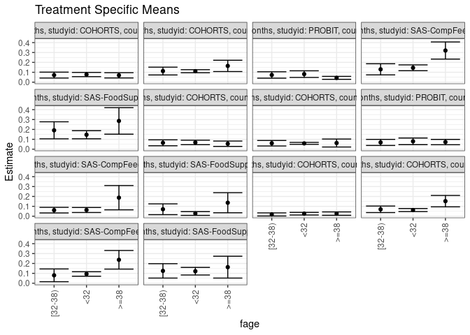

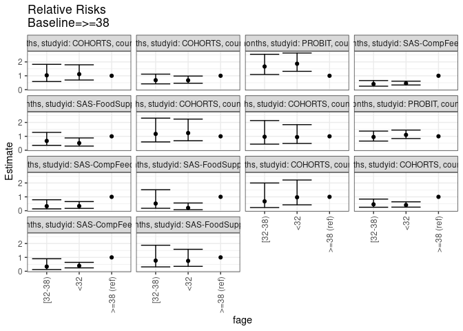

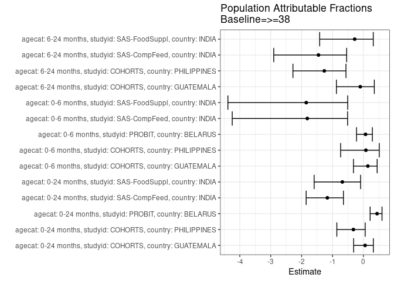

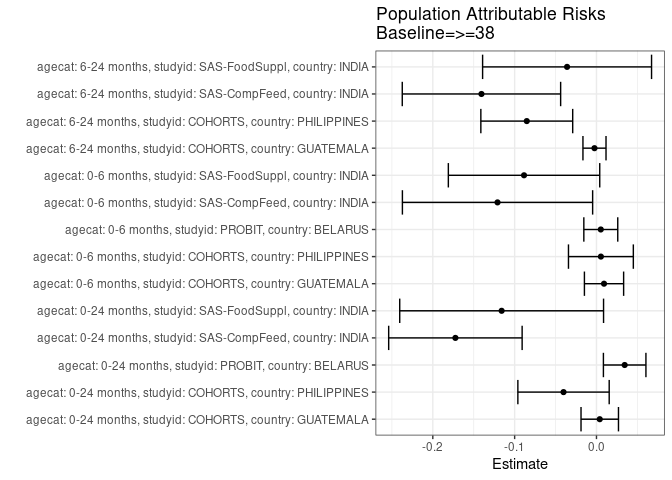

## Results Table

### Parameter: TSM

| agecat | studyid | country | intervention_level | baseline_level | estimate | ci_lower | ci_upper |
| --- | --- | --- | --- | --- | --- | --- | --- |
| 0-24 months | COHORTS | GUATEMALA | >=38 | NA | 0.0691523 | 0.0426387 | 0.0956659 |
| 0-24 months | COHORTS | GUATEMALA | <32 | NA | 0.0771312 | 0.0556844 | 0.0985779 |
| 0-24 months | COHORTS | GUATEMALA | [32-38) | NA | 0.0714529 | 0.0415154 | 0.1013903 |
| 0-24 months | COHORTS | PHILIPPINES | >=38 | NA | 0.1644495 | 0.1072979 | 0.2216010 |
| 0-24 months | COHORTS | PHILIPPINES | <32 | NA | 0.1106615 | 0.0951993 | 0.1261236 |
| 0-24 months | COHORTS | PHILIPPINES | [32-38) | NA | 0.1122671 | 0.0729228 | 0.1516113 |
| 0-24 months | PROBIT | BELARUS | >=38 | NA | 0.0435673 | 0.0285940 | 0.0585407 |
| 0-24 months | PROBIT | BELARUS | <32 | NA | 0.0813630 | 0.0477299 | 0.1149960 |
| 0-24 months | PROBIT | BELARUS | [32-38) | NA | 0.0726989 | 0.0403628 | 0.1050349 |
| 0-24 months | SAS-CompFeed | INDIA | >=38 | NA | 0.3200684 | 0.2333236 | 0.4068131 |
| 0-24 months | SAS-CompFeed | INDIA | <32 | NA | 0.1453282 | 0.1158332 | 0.1748233 |
| 0-24 months | SAS-CompFeed | INDIA | [32-38) | NA | 0.1297975 | 0.0734113 | 0.1861836 |
| 0-24 months | SAS-FoodSuppl | INDIA | >=38 | NA | 0.2857488 | 0.1517664 | 0.4197311 |
| 0-24 months | SAS-FoodSuppl | INDIA | <32 | NA | 0.1460750 | 0.1051226 | 0.1870274 |
| 0-24 months | SAS-FoodSuppl | INDIA | [32-38) | NA | 0.1909817 | 0.1047733 | 0.2771901 |
| 0-6 months | COHORTS | GUATEMALA | >=38 | NA | 0.0550457 | 0.0279013 | 0.0821902 |
| 0-6 months | COHORTS | GUATEMALA | <32 | NA | 0.0680668 | 0.0454614 | 0.0906721 |
| 0-6 months | COHORTS | GUATEMALA | [32-38) | NA | 0.0645724 | 0.0345710 | 0.0945737 |
| 0-6 months | COHORTS | PHILIPPINES | >=38 | NA | 0.0623231 | 0.0220992 | 0.1025470 |
| 0-6 months | COHORTS | PHILIPPINES | <32 | NA | 0.0588419 | 0.0488924 | 0.0687914 |
| 0-6 months | COHORTS | PHILIPPINES | [32-38) | NA | 0.0601760 | 0.0323244 | 0.0880276 |
| 0-6 months | PROBIT | BELARUS | >=38 | NA | 0.0720208 | 0.0450089 | 0.0990327 |
| 0-6 months | PROBIT | BELARUS | <32 | NA | 0.0795175 | 0.0458170 | 0.1132180 |
| 0-6 months | PROBIT | BELARUS | [32-38) | NA | 0.0685134 | 0.0378606 | 0.0991663 |
| 0-6 months | SAS-CompFeed | INDIA | >=38 | NA | 0.1875000 | 0.0647763 | 0.3102237 |
| 0-6 months | SAS-CompFeed | INDIA | <32 | NA | 0.0627981 | 0.0374492 | 0.0881470 |
| 0-6 months | SAS-CompFeed | INDIA | [32-38) | NA | 0.0612245 | 0.0329168 | 0.0895321 |
| 0-6 months | SAS-FoodSuppl | INDIA | >=38 | NA | 0.1363636 | 0.0348425 | 0.2378848 |
| 0-6 months | SAS-FoodSuppl | INDIA | <32 | NA | 0.0276817 | 0.0087443 | 0.0466190 |
| 0-6 months | SAS-FoodSuppl | INDIA | [32-38) | NA | 0.0705882 | 0.0160716 | 0.1251049 |
| 6-24 months | COHORTS | GUATEMALA | >=38 | NA | 0.0264706 | 0.0093999 | 0.0435413 |
| 6-24 months | COHORTS | GUATEMALA | <32 | NA | 0.0256410 | 0.0123773 | 0.0389047 |
| 6-24 months | COHORTS | GUATEMALA | [32-38) | NA | 0.0179211 | 0.0023476 | 0.0334947 |
| 6-24 months | COHORTS | PHILIPPINES | >=38 | NA | 0.1524548 | 0.0948073 | 0.2101023 |
| 6-24 months | COHORTS | PHILIPPINES | <32 | NA | 0.0621865 | 0.0466958 | 0.0776772 |
| 6-24 months | COHORTS | PHILIPPINES | [32-38) | NA | 0.0700250 | 0.0371004 | 0.1029497 |
| 6-24 months | SAS-CompFeed | INDIA | >=38 | NA | 0.2372385 | 0.1432261 | 0.3312508 |
| 6-24 months | SAS-CompFeed | INDIA | <32 | NA | 0.0937255 | 0.0709249 | 0.1165260 |
| 6-24 months | SAS-CompFeed | INDIA | [32-38) | NA | 0.0801254 | 0.0156168 | 0.1446340 |
| 6-24 months | SAS-FoodSuppl | INDIA | >=38 | NA | 0.1627907 | 0.0523100 | 0.2732714 |
| 6-24 months | SAS-FoodSuppl | INDIA | <32 | NA | 0.1218638 | 0.0834307 | 0.1602969 |
| 6-24 months | SAS-FoodSuppl | INDIA | [32-38) | NA | 0.1250000 | 0.0524390 | 0.1975610 |

### Parameter: E(Y)

| agecat | studyid | country | intervention_level | baseline_level | estimate | ci_lower | ci_upper |
| --- | --- | --- | --- | --- | --- | --- | --- |
| 0-24 months | COHORTS | GUATEMALA | NA | NA | 0.0731518 | 0.0589094 | 0.0873941 |
| 0-24 months | COHORTS | PHILIPPINES | NA | NA | 0.1241919 | 0.1122665 | 0.1361173 |
| 0-24 months | PROBIT | BELARUS | NA | NA | 0.0780194 | 0.0455878 | 0.1104510 |
| 0-24 months | SAS-CompFeed | INDIA | NA | NA | 0.1476821 | 0.1188009 | 0.1765633 |
| 0-24 months | SAS-FoodSuppl | INDIA | NA | NA | 0.1698565 | 0.1338154 | 0.2058975 |
| 0-6 months | COHORTS | GUATEMALA | NA | NA | 0.0642648 | 0.0492598 | 0.0792699 |
| 0-6 months | COHORTS | PHILIPPINES | NA | NA | 0.0677332 | 0.0586452 | 0.0768211 |
| 0-6 months | PROBIT | BELARUS | NA | NA | 0.0772965 | 0.0448202 | 0.1097727 |
| 0-6 months | SAS-CompFeed | INDIA | NA | NA | 0.0665779 | 0.0427569 | 0.0903989 |
| 0-6 months | SAS-FoodSuppl | INDIA | NA | NA | 0.0478469 | 0.0273607 | 0.0683330 |
| 6-24 months | COHORTS | GUATEMALA | NA | NA | 0.0240343 | 0.0152359 | 0.0328328 |
| 6-24 months | COHORTS | PHILIPPINES | NA | NA | 0.0672794 | 0.0578635 | 0.0766953 |
| 6-24 months | SAS-CompFeed | INDIA | NA | NA | 0.0966811 | 0.0731505 | 0.1202117 |
| 6-24 months | SAS-FoodSuppl | INDIA | NA | NA | 0.1268657 | 0.0942904 | 0.1594410 |

### Parameter: RR

| agecat | studyid | country | intervention_level | baseline_level | estimate | ci_lower | ci_upper |
| --- | --- | --- | --- | --- | --- | --- | --- |
| 0-24 months | COHORTS | GUATEMALA | >=38 | >=38 | 1.0000000 | 1.0000000 | 1.0000000 |
| 0-24 months | COHORTS | GUATEMALA | <32 | >=38 | 1.1153806 | 0.6944781 | 1.7913796 |
| 0-24 months | COHORTS | GUATEMALA | [32-38) | >=38 | 1.0332675 | 0.5854897 | 1.8235023 |
| 0-24 months | COHORTS | PHILIPPINES | >=38 | >=38 | 1.0000000 | 1.0000000 | 1.0000000 |
| 0-24 months | COHORTS | PHILIPPINES | <32 | >=38 | 0.6729208 | 0.4627263 | 0.9785966 |
| 0-24 months | COHORTS | PHILIPPINES | [32-38) | >=38 | 0.6826843 | 0.4167101 | 1.1184223 |
| 0-24 months | PROBIT | BELARUS | >=38 | >=38 | 1.0000000 | 1.0000000 | 1.0000000 |
| 0-24 months | PROBIT | BELARUS | <32 | >=38 | 1.8675235 | 1.3211954 | 2.6397640 |
| 0-24 months | PROBIT | BELARUS | [32-38) | >=38 | 1.6686562 | 1.0920910 | 2.5496168 |
| 0-24 months | SAS-CompFeed | INDIA | >=38 | >=38 | 1.0000000 | 1.0000000 | 1.0000000 |
| 0-24 months | SAS-CompFeed | INDIA | <32 | >=38 | 0.4540537 | 0.3373090 | 0.6112044 |
| 0-24 months | SAS-CompFeed | INDIA | [32-38) | >=38 | 0.4055304 | 0.2515152 | 0.6538567 |
| 0-24 months | SAS-FoodSuppl | INDIA | >=38 | >=38 | 1.0000000 | 1.0000000 | 1.0000000 |
| 0-24 months | SAS-FoodSuppl | INDIA | <32 | >=38 | 0.5112007 | 0.2959066 | 0.8831373 |
| 0-24 months | SAS-FoodSuppl | INDIA | [32-38) | >=38 | 0.6683553 | 0.3480024 | 1.2836087 |
| 0-6 months | COHORTS | GUATEMALA | >=38 | >=38 | 1.0000000 | 1.0000000 | 1.0000000 |
| 0-6 months | COHORTS | GUATEMALA | <32 | >=38 | 1.2365494 | 0.6823740 | 2.2407863 |
| 0-6 months | COHORTS | GUATEMALA | [32-38) | >=38 | 1.1730678 | 0.5960533 | 2.3086661 |
| 0-6 months | COHORTS | PHILIPPINES | >=38 | >=38 | 1.0000000 | 1.0000000 | 1.0000000 |
| 0-6 months | COHORTS | PHILIPPINES | <32 | >=38 | 0.9441431 | 0.4844672 | 1.8399721 |
| 0-6 months | COHORTS | PHILIPPINES | [32-38) | >=38 | 0.9655481 | 0.4364742 | 2.1359409 |
| 0-6 months | PROBIT | BELARUS | >=38 | >=38 | 1.0000000 | 1.0000000 | 1.0000000 |
| 0-6 months | PROBIT | BELARUS | <32 | >=38 | 1.1040900 | 0.8405753 | 1.4502147 |
| 0-6 months | PROBIT | BELARUS | [32-38) | >=38 | 0.9513003 | 0.6570560 | 1.3773138 |
| 0-6 months | SAS-CompFeed | INDIA | >=38 | >=38 | 1.0000000 | 1.0000000 | 1.0000000 |
| 0-6 months | SAS-CompFeed | INDIA | <32 | >=38 | 0.3349232 | 0.1704948 | 0.6579294 |
| 0-6 months | SAS-CompFeed | INDIA | [32-38) | >=38 | 0.3265306 | 0.1350830 | 0.7893089 |
| 0-6 months | SAS-FoodSuppl | INDIA | >=38 | >=38 | 1.0000000 | 1.0000000 | 1.0000000 |
| 0-6 months | SAS-FoodSuppl | INDIA | <32 | >=38 | 0.2029988 | 0.0738566 | 0.5579534 |
| 0-6 months | SAS-FoodSuppl | INDIA | [32-38) | >=38 | 0.5176471 | 0.1770741 | 1.5132562 |
| 6-24 months | COHORTS | GUATEMALA | >=38 | >=38 | 1.0000000 | 1.0000000 | 1.0000000 |
| 6-24 months | COHORTS | GUATEMALA | <32 | >=38 | 0.9686610 | 0.4237702 | 2.2141811 |
| 6-24 months | COHORTS | GUATEMALA | [32-38) | >=38 | 0.6770211 | 0.2294185 | 1.9979103 |
| 6-24 months | COHORTS | PHILIPPINES | >=38 | >=38 | 1.0000000 | 1.0000000 | 1.0000000 |
| 6-24 months | COHORTS | PHILIPPINES | <32 | >=38 | 0.4079014 | 0.2593452 | 0.6415526 |
| 6-24 months | COHORTS | PHILIPPINES | [32-38) | >=38 | 0.4593166 | 0.2511607 | 0.8399871 |
| 6-24 months | SAS-CompFeed | INDIA | >=38 | >=38 | 1.0000000 | 1.0000000 | 1.0000000 |
| 6-24 months | SAS-CompFeed | INDIA | <32 | >=38 | 0.3950685 | 0.2435751 | 0.6407845 |
| 6-24 months | SAS-CompFeed | INDIA | [32-38) | >=38 | 0.3377419 | 0.1263507 | 0.9028016 |
| 6-24 months | SAS-FoodSuppl | INDIA | >=38 | >=38 | 1.0000000 | 1.0000000 | 1.0000000 |
| 6-24 months | SAS-FoodSuppl | INDIA | <32 | >=38 | 0.7485919 | 0.3541879 | 1.5821822 |
| 6-24 months | SAS-FoodSuppl | INDIA | [32-38) | >=38 | 0.7678571 | 0.3143617 | 1.8755611 |

### Parameter: PAR

| agecat | studyid | country | intervention_level | baseline_level | estimate | ci_lower | ci_upper |
| --- | --- | --- | --- | --- | --- | --- | --- |
| 0-24 months | COHORTS | GUATEMALA | >=38 | NA | 0.0039994 | -0.0188864 | 0.0268852 |
| 0-24 months | COHORTS | PHILIPPINES | >=38 | NA | -0.0402576 | -0.0960615 | 0.0155464 |
| 0-24 months | PROBIT | BELARUS | >=38 | NA | 0.0344521 | 0.0084756 | 0.0604285 |
| 0-24 months | SAS-CompFeed | INDIA | >=38 | NA | -0.1723863 | -0.2539270 | -0.0908455 |
| 0-24 months | SAS-FoodSuppl | INDIA | >=38 | NA | -0.1158923 | -0.2404366 | 0.0086519 |
| 0-6 months | COHORTS | GUATEMALA | >=38 | NA | 0.0092191 | -0.0147394 | 0.0331776 |
| 0-6 months | COHORTS | PHILIPPINES | >=38 | NA | 0.0054100 | -0.0342206 | 0.0450407 |
| 0-6 months | PROBIT | BELARUS | >=38 | NA | 0.0052756 | -0.0154487 | 0.0260000 |
| 0-6 months | SAS-CompFeed | INDIA | >=38 | NA | -0.1209221 | -0.2371560 | -0.0046882 |
| 0-6 months | SAS-FoodSuppl | INDIA | >=38 | NA | -0.0885167 | -0.1810177 | 0.0039842 |
| 6-24 months | COHORTS | GUATEMALA | >=38 | NA | -0.0024363 | -0.0165334 | 0.0116609 |
| 6-24 months | COHORTS | PHILIPPINES | >=38 | NA | -0.0851754 | -0.1412941 | -0.0290566 |
| 6-24 months | SAS-CompFeed | INDIA | >=38 | NA | -0.1405574 | -0.2373246 | -0.0437901 |
| 6-24 months | SAS-FoodSuppl | INDIA | >=38 | NA | -0.0359250 | -0.1391525 | 0.0673024 |

### Parameter: PAF

| agecat | studyid | country | intervention_level | baseline_level | estimate | ci_lower | ci_upper |
| --- | --- | --- | --- | --- | --- | --- | --- |
| 0-24 months | COHORTS | GUATEMALA | >=38 | NA | 0.0546727 | -0.3158819 | 0.3208785 |
| 0-24 months | COHORTS | PHILIPPINES | >=38 | NA | -0.3241560 | -0.8603236 | 0.0574816 |
| 0-24 months | PROBIT | BELARUS | >=38 | NA | 0.4415837 | 0.2172669 | 0.6016154 |
| 0-24 months | SAS-CompFeed | INDIA | >=38 | NA | -1.1672792 | -1.8527583 | -0.6465114 |
| 0-24 months | SAS-FoodSuppl | INDIA | >=38 | NA | -0.6822957 | -1.5949373 | -0.0906309 |
| 0-6 months | COHORTS | GUATEMALA | >=38 | NA | 0.1434550 | -0.3214926 | 0.4448177 |
| 0-6 months | COHORTS | PHILIPPINES | >=38 | NA | 0.0798727 | -0.7370425 | 0.5126001 |
| 0-6 months | PROBIT | BELARUS | >=38 | NA | 0.0682521 | -0.2226347 | 0.2899317 |
| 0-6 months | SAS-CompFeed | INDIA | >=38 | NA | -1.8162500 | -4.2450610 | -0.5121395 |
| 0-6 months | SAS-FoodSuppl | INDIA | >=38 | NA | -1.8500000 | -4.3856396 | -0.5081774 |
| 6-24 months | COHORTS | GUATEMALA | >=38 | NA | -0.1013655 | -0.8740452 | 0.3527338 |
| 6-24 months | COHORTS | PHILIPPINES | >=38 | NA | -1.2659944 | -2.2808598 | -0.5650564 |
| 6-24 months | SAS-CompFeed | INDIA | >=38 | NA | -1.4538246 | -2.9015677 | -0.5432912 |
| 6-24 months | SAS-FoodSuppl | INDIA | >=38 | NA | -0.2831737 | -1.4153842 | 0.3183135 |